# Lab: Basic Plotting in R

Xuemao Zhang

June 24, 2019

## Introduction

- In this session, we analyze the famous (Fisher’s or Anderson’s) iris data from the R library `datasets`.

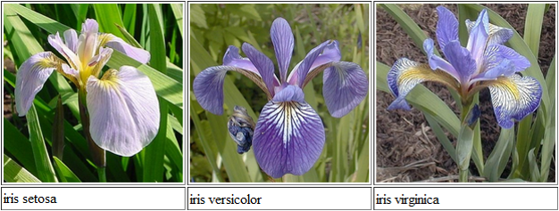

- Install the following package if you don’t have it.

```
                install.packages("datasets");
                #library(datasets); #it is loaded automatically
```

- The data set gives the measurements in centimeters of the variables sepal length and width and petal length and width, respectively, for 50 flowers from each of 3 species of iris. The species are Iris setosa, versicolor, and virginica.
- We consider summary statistics of the data.
- We consider Histogram and Density Plot, Box plot, Bar charts, scatter plot, and pairwise scatter plot.

## Data summary

```r
data1 = iris;   # ?iris
dim(data1);
```

```
## [1] 150   5
```

```r
str(data1);
```

```
## 'data.frame':    150 obs. of  5 variables:
##  $ Sepal.Length: num  5.1 4.9 4.7 4.6 5 5.4 4.6 5 4.4 4.9 ...
##  $ Sepal.Width : num  3.5 3 3.2 3.1 3.6 3.9 3.4 3.4 2.9 3.1 ...
##  $ Petal.Length: num  1.4 1.4 1.3 1.5 1.4 1.7 1.4 1.5 1.4 1.5 ...
##  $ Petal.Width : num  0.2 0.2 0.2 0.2 0.2 0.4 0.3 0.2 0.2 0.1 ...
##  $ Species     : Factor w/ 3 levels "setosa","versicolor",..: 1 1 1 1 1 1 1 1 1 1 ...
```

```r
head(data1);
```

```
##   Sepal.Length Sepal.Width Petal.Length Petal.Width Species
## 1          5.1         3.5          1.4         0.2  setosa
## 2          4.9         3.0          1.4         0.2  setosa
## 3          4.7         3.2          1.3         0.2  setosa
## 4          4.6         3.1          1.5         0.2  setosa
## 5          5.0         3.6          1.4         0.2  setosa
## 6          5.4         3.9          1.7         0.4  setosa
```

```r
tail(data1);
```

```
##     Sepal.Length Sepal.Width Petal.Length Petal.Width   Species
## 145          6.7         3.3          5.7         2.5 virginica
## 146          6.7         3.0          5.2         2.3 virginica
## 147          6.3         2.5          5.0         1.9 virginica
## 148          6.5         3.0          5.2         2.0 virginica
## 149          6.2         3.4          5.4         2.3 virginica
## 150          5.9         3.0          5.1         1.8 virginica
```

```r
summary(data1);
```

```
##   Sepal.Length    Sepal.Width     Petal.Length    Petal.Width
##  Min.   :4.300   Min.   :2.000   Min.   :1.000   Min.   :0.100
##  1st Qu.:5.100   1st Qu.:2.800   1st Qu.:1.600   1st Qu.:0.300
##  Median :5.800   Median :3.000   Median :4.350   Median :1.300
##  Mean   :5.843   Mean   :3.057   Mean   :3.758   Mean   :1.199
##  3rd Qu.:6.400   3rd Qu.:3.300   3rd Qu.:5.100   3rd Qu.:1.800
##  Max.   :7.900   Max.   :4.400   Max.   :6.900   Max.   :2.500
##        Species
##  setosa    :50
##  versicolor:50
##  virginica :50
##
##
##
```

## Graphics

### Histograms and density plots

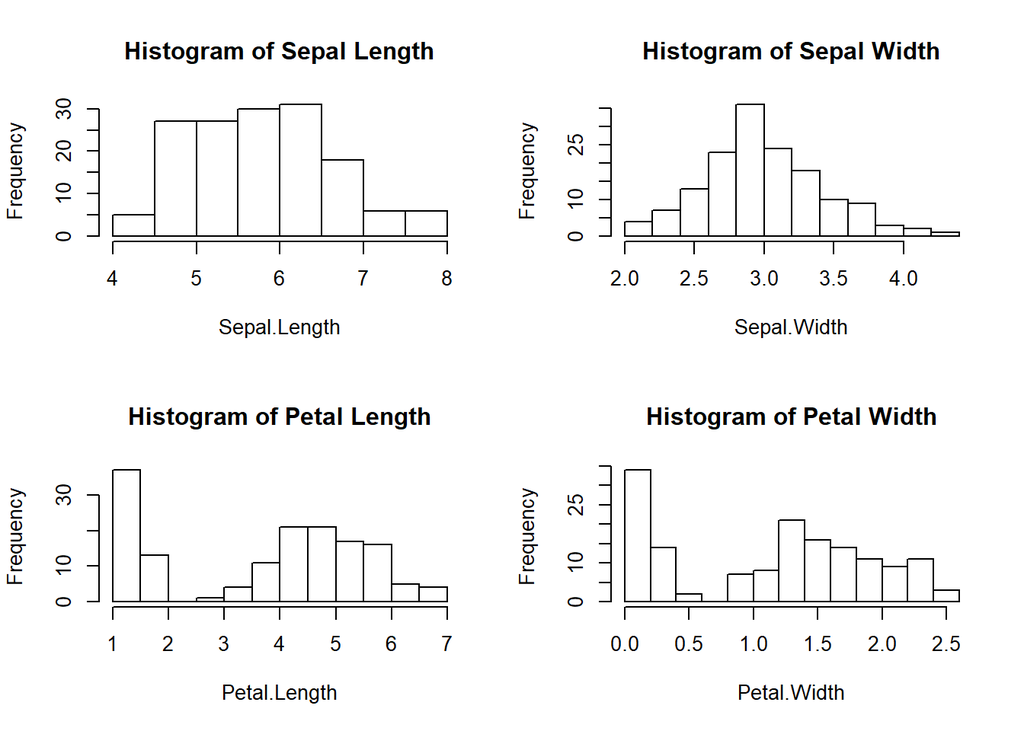

```r
Sepal.Length = data1$Sepal.Length;
Sepal.Width = data1$Sepal.Width;
Petal.Length = data1$Petal.Length;
Petal.Width= data1$Petal.Width;
# These four variables are numerical

par(mfrow=c(2,2));
hist(Sepal.Length, main='Histogram of Sepal Length');
hist(Sepal.Width, main='Histogram of Sepal Width');
hist(Petal.Length, main='Histogram of Petal Length');
hist(Petal.Width, main='Histogram of Petal Width');
```

- We may prefer to see both the histogram and density plot for each variable. But we should consider **relative frequecny** histograms using the option `freq=F`.
- After the `hist()` function, we add the density curve using the `lines()` function.

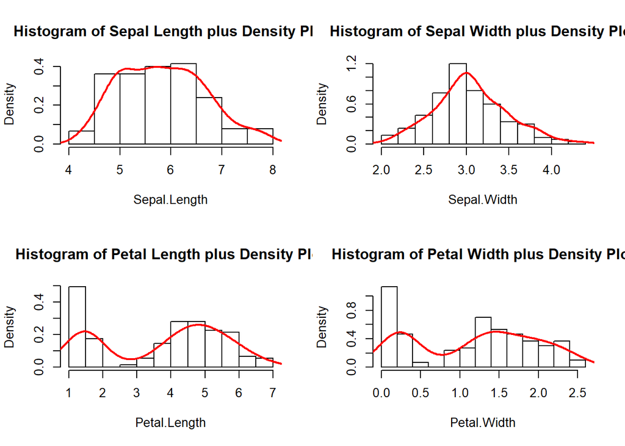

```r
par(mfrow=c(2,2));
hist(Sepal.Length, freq=F, main='Histogram of Sepal Length plus Density Plot');
lines(density(Sepal.Length), col=2, lty=1, lwd=2);

hist(Sepal.Width, freq=F, main='Histogram of Sepal Width plus Density Plot');
lines(density(Sepal.Width), col=2, lty=1, lwd=2);

hist(Petal.Length, freq=F, main='Histogram of Petal Length plus Density Plot');
lines(density(Petal.Length), col=2, lty=1, lwd=2);

hist(Petal.Width, freq=F, main='Histogram of Petal Width plus Density Plot');
lines(density(Petal.Width), col=2, lty=1, lwd=2);
```

### Box plots

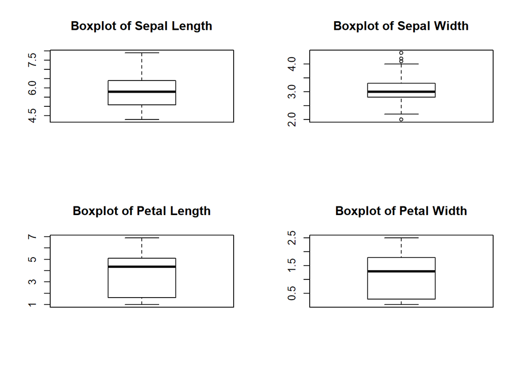

```r
par(mfrow=c(2,2));
boxplot(Sepal.Length, main='Boxplot of Sepal Length');
boxplot(Sepal.Width, main='Boxplot of Sepal Width'); #outliers
boxplot(Petal.Length, main='Boxplot of Petal Length');
boxplot(Petal.Width, main='Boxplot of Petal Width');
```

- To compare the four varialbes, we plot Side-by-side Boxplot.

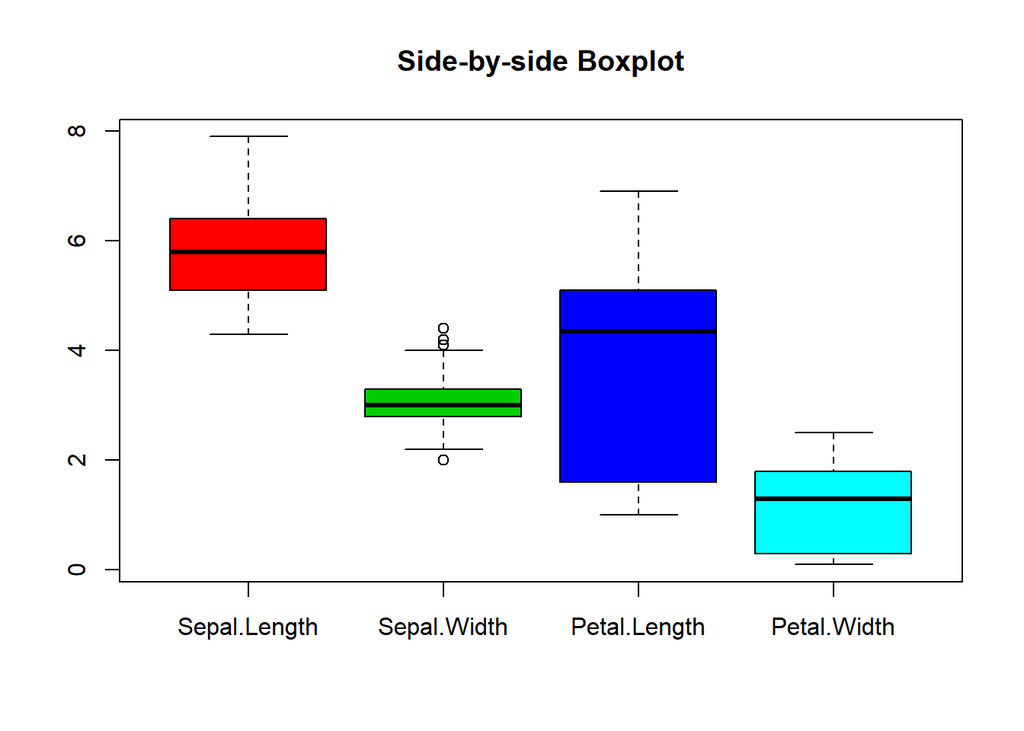

```r
boxplot(data1[,1:4], col=c(2,3,4,5), main='Side-by-side Boxplot');
```

- We may want to see the box plots of each variable for three Species.

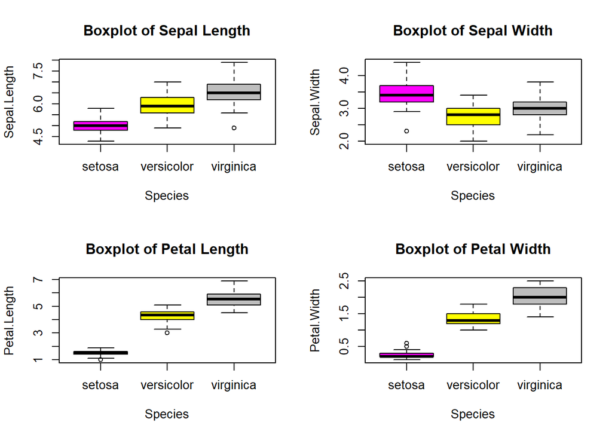

```r
par(mfrow=c(2,2));
boxplot(Sepal.Length~Species, data=data1, col=c(6,7,8), main="Boxplot of Sepal Length");
boxplot(Sepal.Width~Species, data=data1, col=c(6,7,8), main="Boxplot of Sepal Width");
boxplot(Petal.Length~Species, data=data1, col=c(6,7,8), main="Boxplot of Petal Length");
boxplot(Petal.Width~Species, data=data1, col=c(6,7,8), main="Boxplot of Petal Width");
```

### Bar charts

- It can be seen that there are 50 observations for each species.

```r
counts= table(data1$Species );
counts;
```

```
##
##     setosa versicolor  virginica
##         50         50         50
```

- We want to investigate the proportion of a variable exceeding a threshold. In this lab, let’s consider the Sepal.Length variable only.

```r
data1$Flag = data1$Sepal.Length>5; # Add a binary flag, TRUE if Sepal.Length>5, FALSE otherwise.
count1=table(data1$Species[data1$Flag]);  #get the count of three species with Sepal.Length>5
count1;
```

```
##
##     setosa versicolor  virginica
##         22         47         49
```

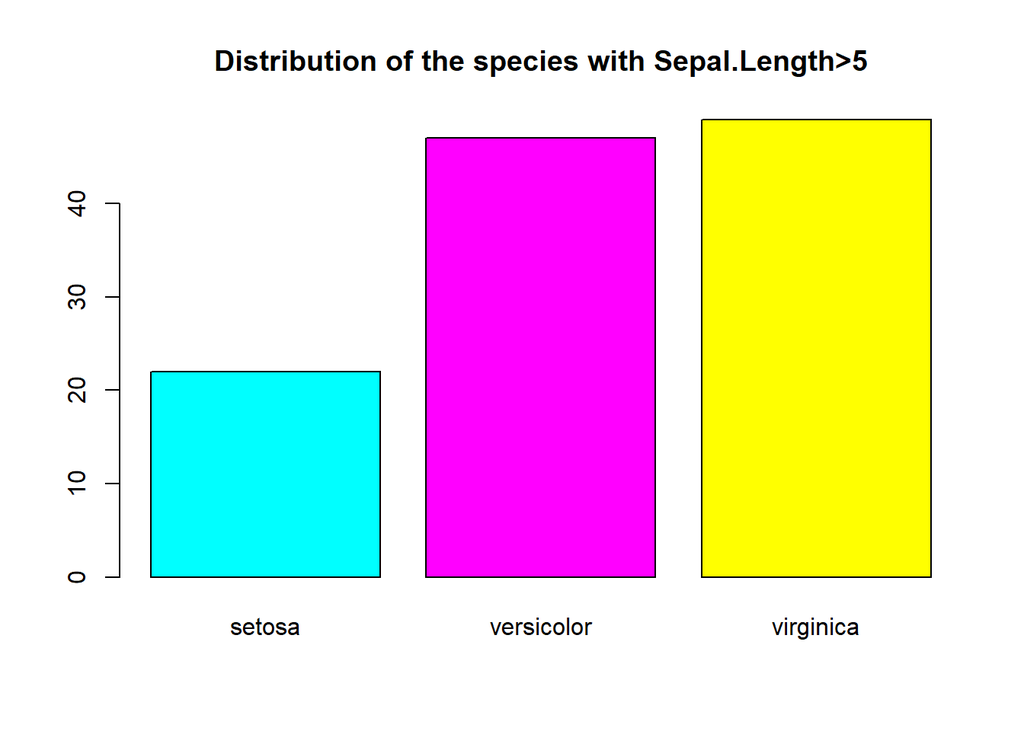

```r
barplot(count1, col=c(5,6,7), main='Distribution of the species with Sepal.Length>5')
```

- Check the complete distribution of the three species

```r
count2=table(data1$Species, data1$Flag);
count2;
```

```
##
##              FALSE TRUE
##   setosa        28   22
##   versicolor     3   47
##   virginica      1   49
```

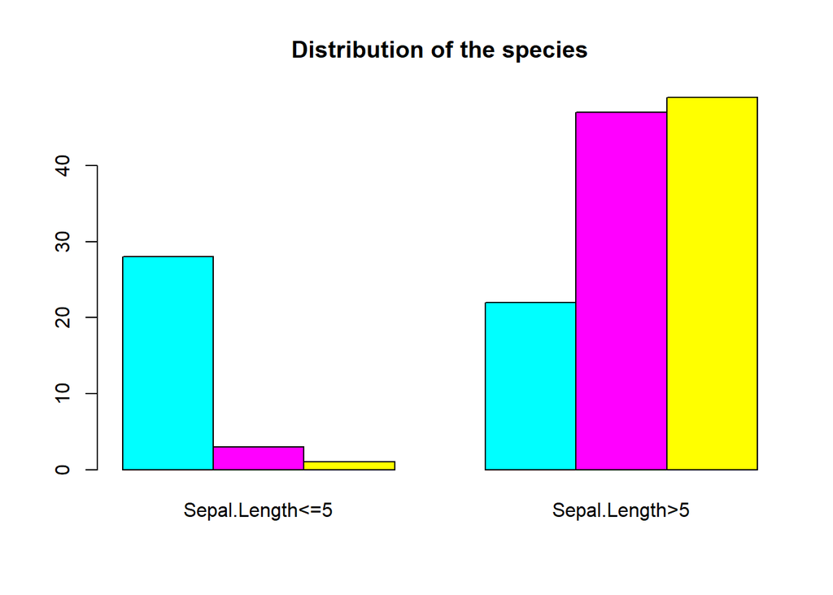

```r
barplot(count2, col=c(5,6,7), beside=TRUE,names.arg=c("Sepal.Length<=5",  "Sepal.Length>5"), main='Distribution of the species');
```

### Scatter plots

- We use scatter plots to check the relationship between two variables

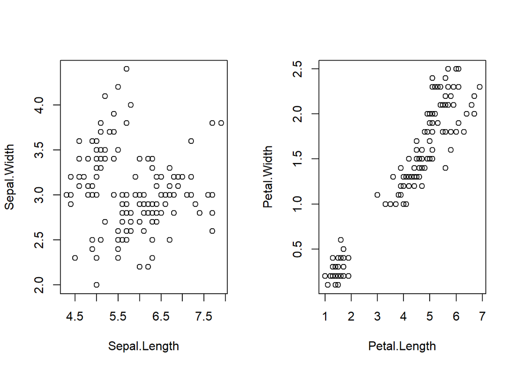

```r
x1=data1$Sepal.Length;
y1=data1$Sepal.Width;
x2=data1$Petal.Length;
y2=data1$Petal.Width;
par(mfrow=c(1,2));
plot(x=x1, y =y1, xlab="Sepal.Length", ylab="Sepal.Width");
plot(x=x2, y = y2, xlab="Petal.Length", ylab="Petal.Width");
```

- Different colors can be specified for different species in a scatter plot.

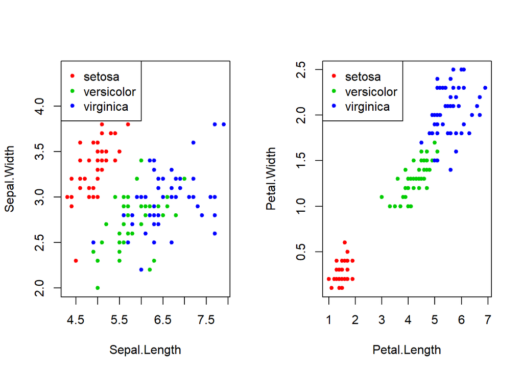

```r
z = data1$Species;
par(mfrow=c(1,2));
plot(x=x1, y =y1, pch=20, col=c(2,3,4)[z],xlab="Sepal.Length", ylab="Sepal.Width");
legend("topleft", levels(z), pch=20, col=c(2,3,4));
plot(x=x2, y = y2, pch=20, col=c(2,3,4)[z],xlab="Petal.Length", ylab="Petal.Width");
legend("topleft", levels(z), pch=20, col=c(2,3,4));
```

- The following is a scatter plot matrix.

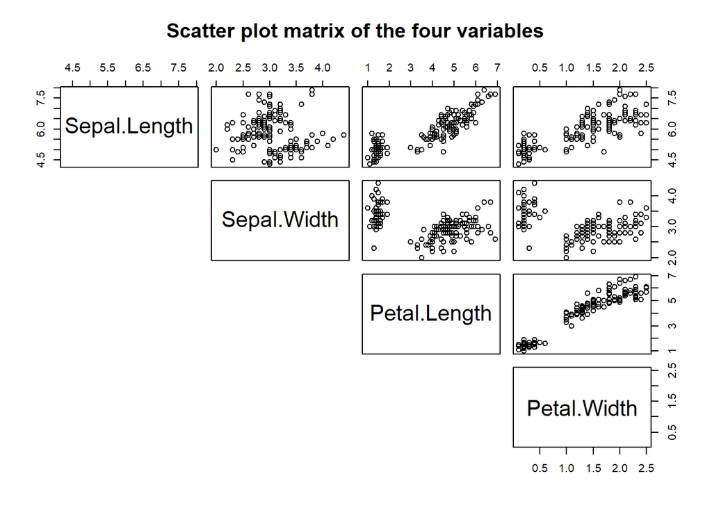

```r
pairs(data1[,1:4], main="Scatter plot matrix of the four variables",lower.panel = NULL);
```

```r
#pairs(~Sepal.Length+Sepal.Width+Petal.Length+Petal.Width,data=data1,lower.panel = NULL);
```

- The following is a scatter plot matrix.
- Again, we can identify the species.

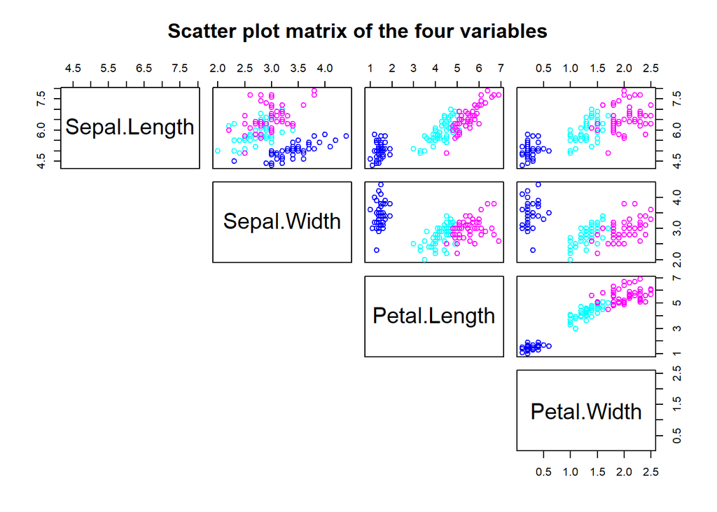

```r
pairs(data1[,1:4], col = c(4,5,6)[data1$Species], main="Scatter plot matrix of the four variables",lower.panel = NULL);
```